# Homework 1

Andżelika Zalewska

12 03 2020

Model Random Forest łączy dane wyjściowe z wielu drzew decyzyjnych, a następnie w końcu opracowuje własne wyniki. Random Forest losowo próbkuje punkty danych i zmienne w każdym tworzonym drzewie, a następnie łączy wynik na końcu. Usuwa błędy, które może wprowadzić model drzewa decyzyjnego. Ponadto znacznie poprawia moc predykcyjną. Na poniżej przedstawionych danych zbuduję model z pakietu randomForest, początkowo dla domyślnych parametrów. Zmienną odpowiedzi będzie zmienna “PURCHASE”, a predyktorami użytymi do modelu pozostałe zmienne.

```r
library(randomForest)
library(Information)
require(pROC)
```

Zbiory danych: (1) ‘train’ i (2) ‘valid’ z pakietu R ‘Information’.

```r
data(train)
data(valid)
```

Usuwam ze zbioru testowego i walidacyjnego zmienną “UNIQUE_ID”

```r
train <- train[,-70]
valid <- valid[,-60]
```

Aby móc zbudować model dla klasyfikacji binarnej zamieniam zmienną odpowiedzi typu ‘numeric’ na zmienną typu ‘factor’.

```r
train$PURCHASE <- as.factor(train$PURCHASE)
valid$PURCHASE <- as.factor(valid$PURCHASE)
```

Początkowy model z domyślnie ustawionymi parametrami.

```r
model1 <- randomForest(PURCHASE ~ ., data = train, importance = TRUE)
model1
```

```
##
## Call:
##  randomForest(formula = PURCHASE ~ ., data = train, importance = TRUE)
##                Type of random forest: classification
##                      Number of trees: 500
## No. of variables tried at each split: 8
##
##         OOB estimate of  error rate: 17.11%
## Confusion matrix:
##      0   1 class.error
## 0 7824 180  0.02248876
## 1 1531 465  0.76703407
```

Predykcja na zbiorze treningowym. Sprawdzenie precyzji klasyfikacji na zbiorze treningowym.

```r
predTrain <- predict(model1, train, type = "class")
table(predTrain, train$PURCHASE)
```

```
##
## predTrain    0    1
##         0 8004   56
##         1    0 1940
```

```r
mean(predTrain == train$PURCHASE)
```

```
## [1] 0.9944
```

Predykcja na zbiorze walidacyjnym. Sprawdzenie precyzji klasyfikacji na zbiorze walidacyjnym.

```r
predValid <- predict(model1, valid, type = "class")
mean(predValid == valid$PURCHASE)
```

```
## [1] 0.8365
```

```r
table(predValid,valid$PURCHASE)
```

```
##
## predValid    0    1
##         0 7853 1501
##         1  134  512
```

Sprawdzenie istotności zmiennych i ich wpływu na precyzję predykcji.

```r
importance(model1)
```

```
##                                          0             1 MeanDecreaseAccuracy
## TREATMENT                        7.3315387   7.313190489             9.588309
## M_SNC_MST_RCNT_ACT_OPN          15.2806647  -0.276264590            15.289552
## TOT_HI_CRDT_CRDT_LMT            18.2741651   4.373956974            20.266678
## RATIO_BAL_TO_HI_CRDT            14.7394609  12.804428956            19.410555
## AGRGT_BAL_ALL_XCLD_MRTG         16.2402613  -8.956940894            15.538230
## N_OF_SATISFY_FNC_REV_ACTS        8.9765060   6.750048917            11.308686
## AVG_BAL_ALL_FNC_REV_ACTS         4.5648239   3.450258260             5.946821
## N_BANK_INSTLACTS                12.4242351  -0.597919943            11.878964
## M_SNCOLDST_BNKINSTL_ACTOPN      13.0081181   1.019230015            12.843465
## N_FNC_INSTLACTS                 17.3260164   1.826913924            17.888567
## N_SATISFY_INSTL_ACTS             9.1903906  -3.539856365             8.015449
## M_SNC_MSTREC_INSTL_TRD_OPN      16.2170465   1.609723707            17.072461
## TOT_INSTL_HI_CRDT_CRDT_LMT      10.4222944  -7.886460970             9.705832
## M_SNC_OLDST_MRTG_ACT_OPN        14.4207035   4.478163395            15.941880
## M_SNC_MSTRCNT_MRTG_ACT_UPD       4.8076966  -2.744393215             3.436979
## M_SNC_MST_RCNT_MRTG_DEAL         4.9911369   0.685603834             5.270414
## N30D_ORWRS_RTNG_MRTG_ACTS        3.4608755  -0.680030329             3.138325
## N_OF_MRTG_ACTS_DLINQ_24M         1.5877286   2.447952878             2.231396
## N_SATISFY_PRSNL_FNC_ACTS         7.3611460  -2.035735135             7.279710
## RATIO_PRSNL_FNC_BAL2HICRDT       7.6229634   1.918328584             8.215571
## TOT_OTHRFIN_HICRDT_CRDTLMT       8.5320811  -4.297413580             7.764868
## N_SATISFY_OIL_NATIONL_ACTS       5.6077354   9.598853333             9.299329
## M_SNCOLDST_OIL_NTN_TRD_OPN       6.3624108  10.046080078            10.776170
## N_BC_ACTS_OPN_IN_12M             4.5801949   3.132319453             5.418172
## N_BC_ACTS_OPN_IN_24M             4.2001373   6.492774427             6.992036
## AVG_BAL_ALL_PRM_BC_ACTS          8.8711532  12.768588481            11.856601
## N_RETAIL_ACTS_OPN_IN_24M         8.8908113  -4.037357911             6.479588
## M_SNC_OLDST_RETAIL_ACT_OPN      22.3489860   4.701337945            23.141103
## RATIO_RETAIL_BAL2HI_CRDT         9.1402472   0.451635988             9.528765
## TOT_BAL_ALL_DPT_STORE_ACTS       7.7204927  -5.440024391             6.973659
## N_30D_RATINGS                   12.0397296  -3.842015169            11.371540
## N_120D_RATINGS                   4.3186522  -2.423402371             3.218474
## N_30D_AND_60D_RATINGS           11.0643586  -4.791016806             9.869093
## N_ACTS_WITH_MXD_3_IN_24M         2.0426241   0.307946826             2.110132
## N_ACTS_WITH_MXD_4_IN_24M         2.7282399  -0.856450683             2.416309
## PRCNT_OF_ACTS_NEVER_DLQNT       16.3309137   1.071898520            18.161336
## N_ACTS_90D_PLS_LTE_IN_6M         6.4049926  -4.580833542             5.304363
## TOT_NOW_LTE                      6.8460670  -3.354880653             6.029420
## N_DEROG_PUB_RECS                 4.3477986  -0.744672424             4.250913
```

[output cut: 83 more lines]

```
## MAX_MRTG_CLOSE_DATE                    56.554005
## UPSCALE_OPEN_DATE_YRS                  50.006733
## STUDENT_OPEN_DATE_YRS                  10.549374
## FNC_CARD_OPEN_DATE_YRS                 24.857994
## AGE                                   112.482432
## D_DEPTCARD                             45.254505
## D_REGION_A                             22.830666
## D_REGION_B                             16.632244
## D_REGION_C                             19.692427
## D_NA_M_SNC_MST_RCNT_ACT_OPN             5.139831
## D_NA_AVG_BAL_ALL_FNC_REV_ACTS          17.385222
## D_NA_M_SNCOLDST_BNKINSTL_ACTOPN        15.262588
## D_NA_M_SNC_OLDST_MRTG_ACT_OPN          17.956795
## D_NA_M_SNC_MST_RCNT_MRTG_DEAL           4.654828
## D_NA_RATIO_PRSNL_FNC_BAL2HICRDT         9.061288
```

AUC i ROC

```r
rf.roc<-roc(train$PURCHASE,model1$votes[,2])
auc(rf.roc)
```

```
## Area under the curve: 0.8196
```

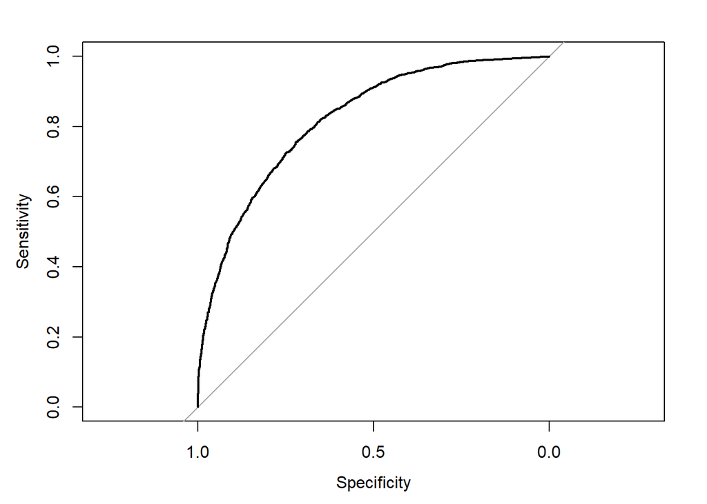

Przy użyciu pętli próbuję dopracować model, zmieniając „mtry”. Można próbować poprawić model random forest, zmieniając liczbę drzew (ntree) i liczbę zmiennych losowo próbkowanych na każdym etapie (mtry).

ntree: liczba drzew. Nie należy ustawiać zbyt małej liczby, aby zapewnić, że każdy wiersz wejściowy zostanie uwzględniony w predykcji co najmniej kilka razy.

mtry: liczba zmiennych losowo próbkowanych jako kandydaci przy każdym podziale.

```r
accuracy=c()
AUC=c()
for (i in 3:8) {
  model3 <- randomForest(PURCHASE ~ ., data = train, ntree = 500, mtry = i, importance = TRUE)
  predValid <- predict(model3, valid, type = "class")
  accuracy[i-2] = mean(predValid == valid$PURCHASE)
  rf.roc<-roc(train$PURCHASE,model3$votes[,2])
  AUC[i-2] = auc(rf.roc)
}
```

```r
accuracy
```

```
## [1] 0.8280 0.8320 0.8348 0.8334 0.8355 0.8367
```

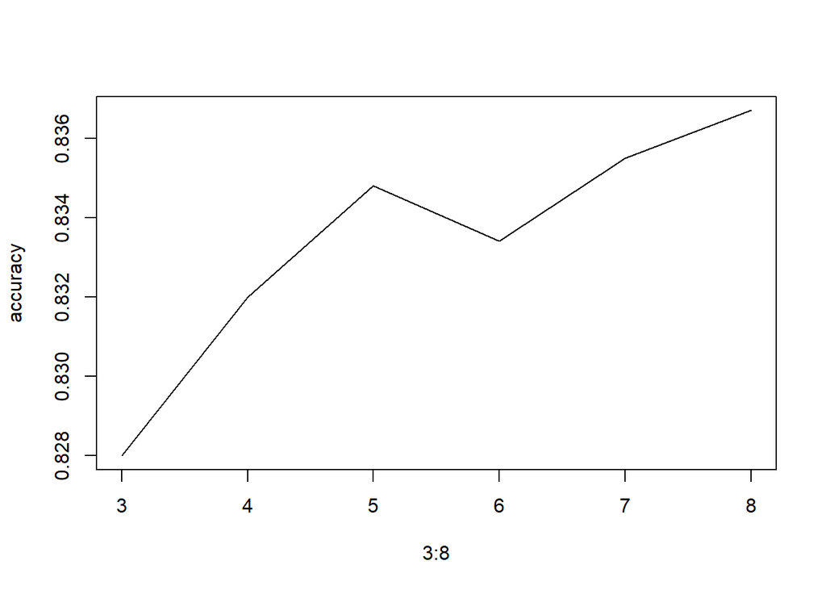

```r
AUC
```

```
## [1] 0.8141899 0.8167218 0.8186070 0.8203276 0.8204804 0.8180552
```

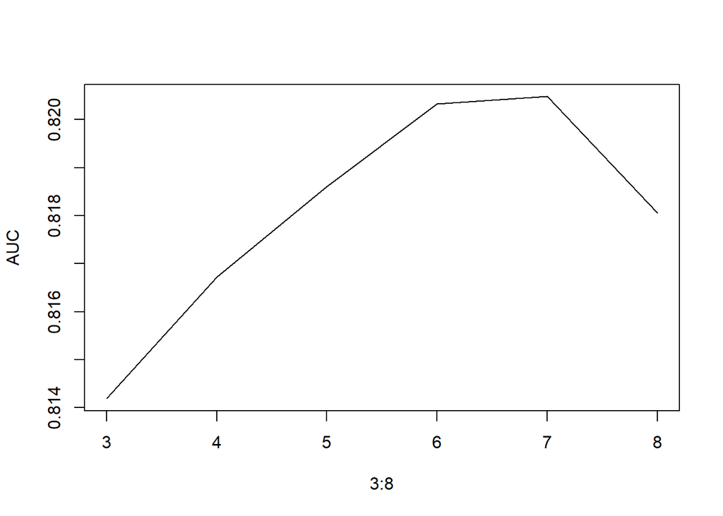